# Exercise 1

### Correlation Analysis 2

Looking at the results from the previous correlation analysis has made me think that although there might not be a correlation between lattitude/longitude and listing price, that does not mean that there is not a correlation between location and listing price. For my next correlation analysis, I will create two new attributes called “lat_distance_from_mean” and “long_distance_from_mean” which will store the latitudinal and longitudinal distances from the mean latitude and mean longitude for each listing.

```r
# get means
mean_lat = mean(listings$latitude)
mean_long = mean(listings$longitude)

# create new columns
listings$lat_distance_from_mean = abs(listings$latitude - mean_lat)
listings$long_distance_from_mean = abs(listings$longitude - mean_long)
```

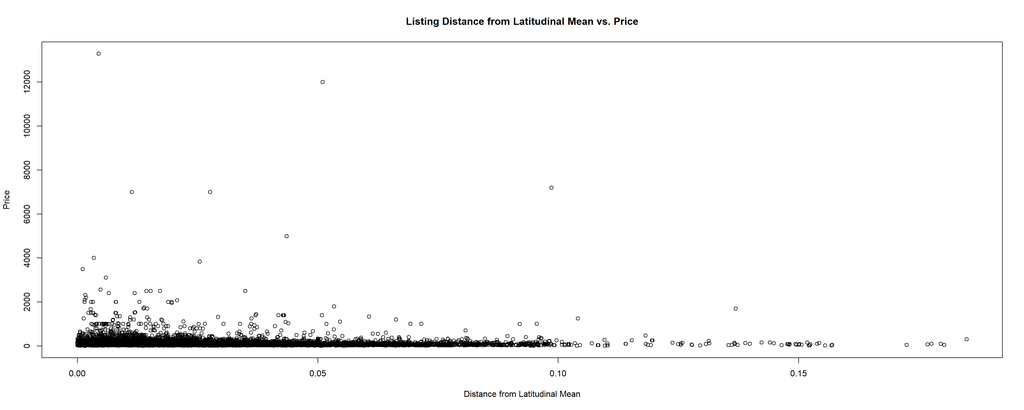

```r
# plot listing distance from latitudinal mean vs price
plot(listings$lat_distance_from_mean, listings$price,
     main = "Listing Distance from Latitudinal Mean vs. Price",
     xlab = "Distance from Latitudinal Mean",
     ylab = "Price")
```

```r
# correlation between home latitude and price
cor(listings$lat_distance_from_mean, listings$price, use = "complete.obs")
```

```
## [1] -0.0381459
```

As can be seen above in the plot and in the correlation calculation, there is no correlation between listing distance from latitudinal mean and price.

```r
length(listings$long_distance_from_mean)
```

```
## [1] 12333
```

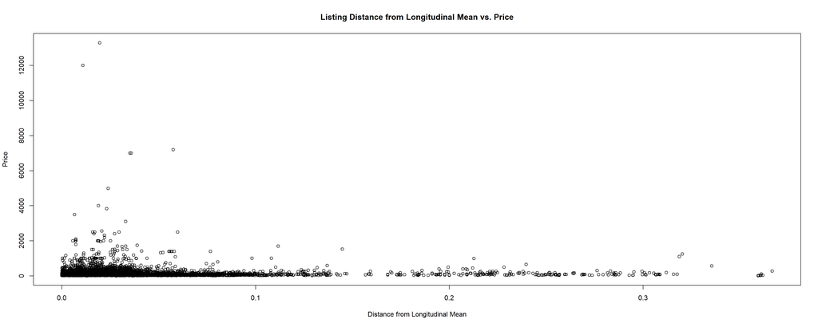

```r
# plot listing distance form longitudinal mean vs price
plot(listings$long_distance_from_mean, listings$price,
     main = "Listing Distance from Longitudinal Mean vs. Price",
     xlab = "Distance from Longitudinal Mean",
     ylab = "Price")
```

```r
# correlation between listing distance form longitudinal mean and price
cor(listings$longitude, listings$price, use = "complete.obs")
```

```
## [1] 0.02076558
```

Again, perhaps some inference can be made by looking at each individual room type.

```r
# get 'Entire home/apt' data
homes <- listings[listings$room_type == "Entire home/apt",]
```

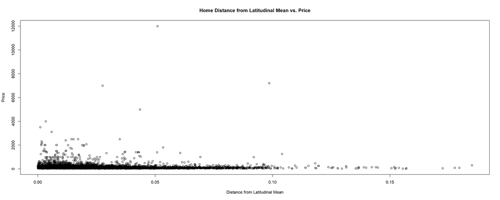

```r
# plot home distance from latitudinal mean vs price
plot(homes$lat_distance_from_mean, homes$price,
     main = "Home Distance from Latitudinal Mean vs. Price",
     xlab = "Distance from Latitudinal Mean",
     ylab = "Price")
```

```r
# correlation between home distance from latitudinal mean and price
cor(homes$lat_distance_from_mean, homes$price, use = "complete.obs")
```

```
## [1] -0.04092493
```

As can be seen above in the plot and in the correlation calculation, there is no correlation between home distance from latitudinal mean and price.

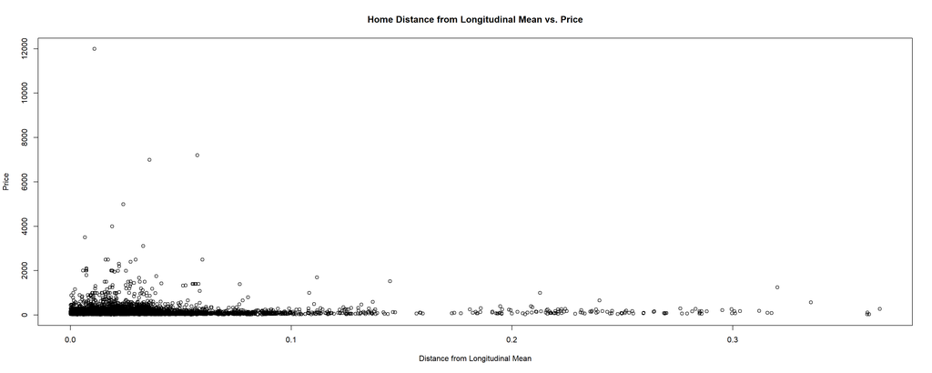

```r
# plot home distance from longitudinal mean vs price
plot(homes$long_distance_from_mean, homes$price,
     main = "Home Distance from Longitudinal Mean vs. Price",
     xlab = "Distance from Longitudinal Mean",
     ylab = "Price")
```

```r
# correlation between home distance from longitudinal mean and price
cor(homes$long_distance_from_mean, homes$price, use = "complete.obs")
```

```
## [1] 0.008814093
```

As can be seen above in the plot and in the correlation calculation, there is no correlation between home distance from longitudinal mean and price.

```r
# get 'Hotel room' data
hotels <- listings[listings$room_type == "Hotel room",]
```

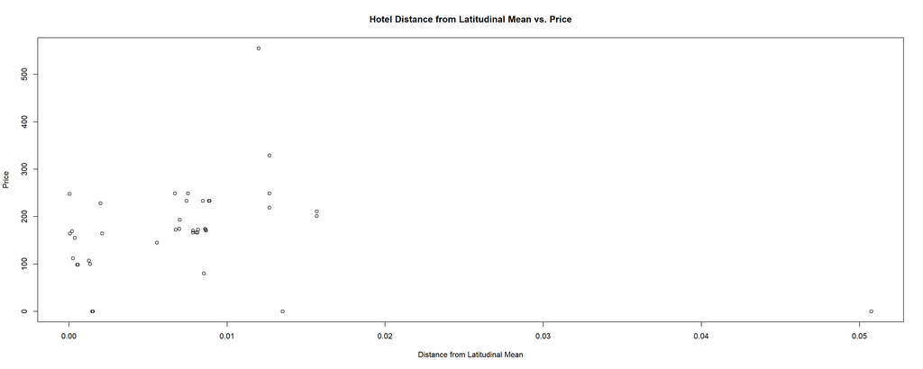

```r
# plot hotel distance from latitudinal mean vs price
plot(hotels$lat_distance_from_mean, hotels$price,
     main = "Hotel Distance from Latitudinal Mean vs. Price",
     xlab = "Distance from Latitudinal Mean",
     ylab = "Price")
```

```r
# correlation between hotel distance from latitudinal mean and price
cor(hotels$lat_distance_from_mean, hotels$price, use = "complete.obs")
```

```
## [1] -0.02835184
```

As can be seen above in the plot and in the correlation calculation, there is no correlation between hotel distance from latitudinal mean and price.

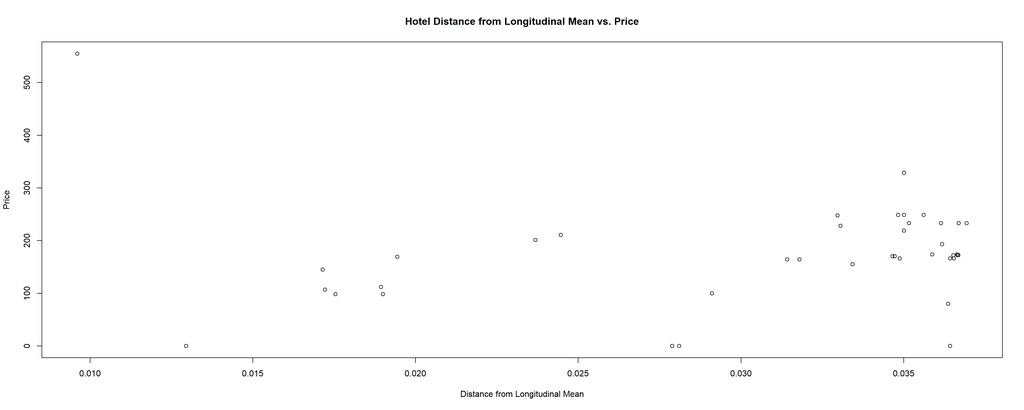

```r
# plot hotel distance from longitudinal mean vs price
plot(hotels$long_distance_from_mean, hotels$price,
     main = "Hotel Distance from Longitudinal Mean vs. Price",
     xlab = "Distance from Longitudinal Mean",
     ylab = "Price")
```

```r
# correlation between hotel distance from longitudinal mean and price
cor(hotels$long_distance_from_mean, hotels$price, use = "complete.obs")
```

```
## [1] 0.0480779
```

As can be seen above in the plot and in the correlation calculation, there is no correlation between hotel distance from longitudinal mean and price.

```r
# get 'Private room' data
singles <- listings[listings$room_type == "Hotel room",]
```

[figure not shown]

```r
# plot private room distance from latitudinal mean vs price
plot(singles$lat_distance_from_mean, singles$price,
     main = "Private Room Distance from Latitudinal Mean vs. Price",
     xlab = "Distance from Latitudinal Mean",
     ylab = "Price")
```

```r
# correlation between private room distance from latitudinal mean and price
cor(singles$lat_distance_from_mean, singles$price, use = "complete.obs")
```

```
## [1] -0.02835184
```

[figure not shown]

```r
# plot private room distance from longitudinal mean vs price
plot(singles$long_distance_from_mean, singles$price,
     main = "Private Room Distance from Longitudinal Mean vs. Price",
     xlab = "Distance from Longitudinal Mean",
     ylab = "Price")
```

```r
# correlation between private room distance from longitudinal mean and price
cor(singles$long_distance_from_mean, singles$price, use = "complete.obs")
```

```
## [1] 0.0480779
```

```r
# get 'Shared room' data
shared <- listings[listings$room_type == "Shared room",]
```

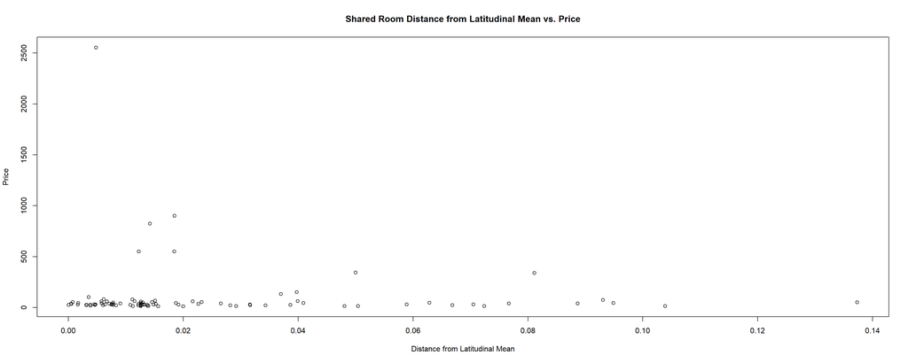

```r
# plot shared room distance from latitudinal mean vs price
plot(shared$lat_distance_from_mean, shared$price,
     main = "Shared Room Distance from Latitudinal Mean vs. Price",
     xlab = "Distance from Latitudinal Mean",
     ylab = "Price")
```

```r
# correlation between shared room distance from latitudinal mean and price
cor(shared$lat_distance_from_mean, shared$price, use = "complete.obs")
```

```
## [1] -0.04814291
```

As can be seen above in the plot and in the correlation calculation, there is no correlation between shared room distance from latitudinal mean and price.

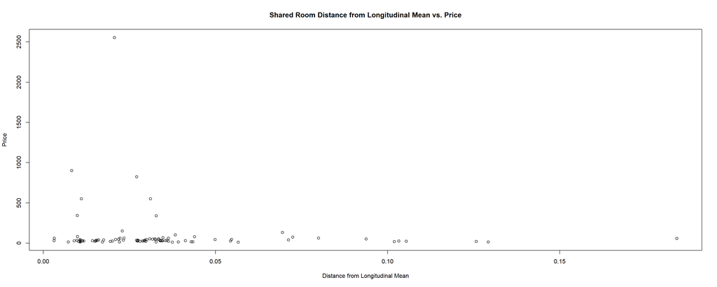

```r
# plot shared room distance from longitudinal mean vs price
plot(shared$long_distance_from_mean, shared$price,
     main = "Shared Room Distance from Longitudinal Mean vs. Price",
     xlab = "Distance from Longitudinal Mean",
     ylab = "Price")
```

```r
# correlation between private room distance from longitudinal mean and price
cor(shared$long_distance_from_mean, shared$price, use = "complete.obs")
```

```
## [1] -0.08771857
```

As can be seen above in the plot and in the correlation calculation, there is no correlation between shared room distance from longitudinal mean and price.

Contrary to my initial belief, no correlation was found between the distance from the mean latitude or longitude.

### Correlation Analysis 3

```r
# get private room data
private_room_data = listings[listings$room_type == "Entire home/apt",]
```

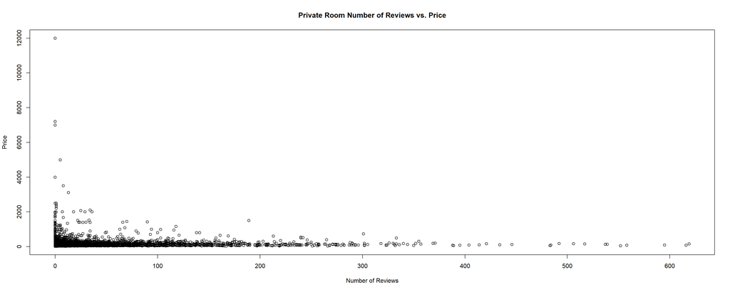

```r
# plot private room total reviews vs. price
plot(private_room_data$number_of_reviews, private_room_data$price,
     main = "Private Room Number of Reviews vs. Price",
     xlab = "Number of Reviews",
     ylab = "Price")
```

```r
# determine correlation between private room number of reviews and price
cor(private_room_data$number_of_reviews, private_room_data$price, use = "complete.obs")
```

```
## [1] 0.004521297
```